# Getting Started

Start by going to "Runtime", select "Change Runtime Type", ensure that "R" is selected, and click "Save".

Next, run the following two boxes. The first checks that we can do basic calculations. The second is an "R" command (generate 10 standard normal random variates), to make sure that "R" is working...

```r
1 + 4
```

5

```r
rnorm(10)
```

1. 1.13190576364287

2. -0.0880936398926083

3. 0.798955268636384

4. -0.355102991911502

5. 0.548632268603057

6. 0.358549847187284

7. -0.216087455814442

8. 1.5285581196557

9. 0.128679037030529

10. 0.271882733385612

# Import and Describe the Data

First, we import the data from Github. See the repo "https://github.com/OpenActTextDev/ActuarialRegression" for other datasets.

```r
Hexpend <- read.csv("https://raw.githubusercontent.com/OpenActTextDev/ActuarialRegression/refs/heads/main/CSVData/HealthExpend.csv", header=TRUE)
```

Just to make sure that data was read in properly, let's look at the structure and do a summary.

```r
str(Hexpend)
summary(Hexpend)
```

[output not shown]

This is the table that appears in the book.

```r
row1 <- c("Not hospitalized" , "$y=0$" , "902 (95.3%)" , "941 (89.3%)" )
row2 <- c("Hospitalized" , "$y=1$ ",  "44 (4.7%)"  , "113 (10.7%)" )
row3 <- c("Total" ,  "", "946"  , "1,054" )
tableout <- rbind(row1, row2, row3)
row.names(tableout) <- NULL
colnames(tableout) <- c("", "", "Male", "Female")
tableout
#TableGen1(TableData=tableout,
#         TextTitle='Hospitalization by Sex',
#         Align='lccc', ColumnSpec=1:3,
#         ColWidth = "3cm")  %>%
#     kableExtra::column_spec(1, width =  "4cm")
```

[output not shown]

We can get some quick summaries with the 'table' function in 'R'.

```r
POSEXP = 1*(Hexpend$EXPENDIP>0)
table(POSEXP)
table(Hexpend$GENDER)
```

```
POSEXP
   0    1
1843  157
```

```
   0    1
 946 1054
```

However, for more complex summarizes, we utilize a library "Hmisc". These needs to be first installed, which takes a couple of minutes in Google Colab.

```r
install.packages("Hmisc")
library(Hmisc)
Hmisc::summarize(POSEXP, Hexpend$GENDER, mean)
```

[output not shown]

Here is some output that we can get from "Hmisc." This example also illustrates how to create functions in "R".

```r
#install.packages("Hmisc")
#library(Hmisc)
#  CREATE A SHORT FUNCTION TO SAVE WORK
fun1 <- function(y){
  options(digits=3)
  temp0 <- cbind(table(y)/length(y),Hmisc::summarize(POSEXP, y, mean))
  temp <- temp0[c(2,1),]
  temp[,c(2,4)] <- round(temp[,c(2,4)], digits=3)
return(cbind(temp[,3],temp[,2],temp[,4]))}

var1 <- fun1(Hexpend$GENDER)
var2 <- fun1(Hexpend$RACE)
var3 <- fun1(Hexpend$REGION)
var4 <- fun1(Hexpend$EDUC)
var5 <- fun1(Hexpend$PHSTAT)
#var6 <- fun1(Hexpend$MPOOR)
var7 <- fun1(Hexpend$ANYLIMIT)
var8 <- fun1(Hexpend$INCOME)
var9 <- fun1(Hexpend$insure)
tableout <- rbind(var1, var2, var3, var4,
                  var5, var7, var8, var9)
tableout
```

A matrix: 16 × 3 of type chr

| 1 | 0.527 | 0.107 |
| --- | --- | --- |
| 0 | 0.473 | 0.047 |
| BLACK | 0.148 | 0.105 |
| ASIAN | 0.043 | 0.047 |
| NORTHEAST | 0.143 | 0.101 |
| MIDWEST | 0.196 | 0.087 |
| HIGHSCH | 0.433 | 0.079 |
| COLLEGE | 0.272 | 0.068 |
| FAIR | 0.098 | 0.081 |
| EXCE | 0.254 | 0.051 |
| 1 | 0.223 | 0.146 |
| 0 | 0.777 | 0.059 |
| LINCOME | 0.158 | 0.083 |
| HINCOME | 0.316 | 0.054 |
| 1 | 0.777 | 0.092 |
| 0 | 0.222 | 0.031 |

# Logistic Regression

```r
#  Table 11.5
Hexpend$POSEXP = 1*(Hexpend$EXPENDIP>0)

#  CHANGE REFERENCE LEVELS TO AGREE WITH BOOK (DONE IN SAS)
attach(Hexpend)
RACE = relevel(factor(RACE),ref="WHITE")
REGION = relevel(factor(REGION),ref="WEST")
EDUC = relevel(factor(EDUC),ref="LHIGHSC")
PHSTAT = relevel(factor(PHSTAT),ref="EXCE")
INCOME = relevel(factor(INCOME),ref="POOR")

# FULL LOGIT MODEL;
PosExpglmFull = glm(POSEXP~AGE+GENDER
 +factor(RACE)+ factor(REGION)+factor(EDUC)
 +factor(PHSTAT)+ANYLIMIT+factor(INCOME)
 +insure, family=binomial(link=logit))
#summary(PosExpglmFull)
Table1 <- summary(PosExpglmFull)
Table1Red <- round(Table1$coefficients[,c(1,3)], digits=3)
Table1Red
```

A matrix: 22 × 2 of type dbl

|  | Estimate | z value |
| --- | --- | --- |
| (Intercept) | -4.239 | -8.981 |
| AGE | -0.001 | -0.170 |
| GENDER | 0.734 | 3.815 |
| factor(RACE)ASIAN | -0.222 | -0.417 |
| factor(RACE)BLACK | -0.004 | -0.017 |
| factor(RACE)NATIV | 0.602 | 0.913 |
| factor(RACE)OTHER | -0.215 | -0.320 |
| factor(REGION)MIDWEST | 0.518 | 1.887 |
| factor(REGION)NORTHEAST | 0.605 | 2.099 |
| factor(REGION)SOUTH | 0.332 | 1.355 |
| factor(EDUC)COLLEGE | 0.068 | 0.255 |
| factor(EDUC)HIGHSCH | 0.005 | 0.025 |
| factor(PHSTAT)FAIR | 0.115 | 0.321 |
| factor(PHSTAT)GOOD | 0.371 | 1.409 |
| factor(PHSTAT)POOR | 1.668 | 4.524 |
| factor(PHSTAT)VGOO | 0.175 | 0.654 |
| ANYLIMIT | 0.554 | 2.651 |
| factor(INCOME)HINCOME | -0.911 | -3.082 |
| factor(INCOME)LINCOME | -0.404 | -1.431 |
| factor(INCOME)MINCOME | -0.600 | -2.288 |
| factor(INCOME)NPOOR | -0.199 | -0.522 |
| insure | 1.232 | 4.041 |

```r
# REDUCED LOGIT MODEL;
PosExpglmRed = glm(POSEXP~GENDER + factor(RACE) +
        +factor(REGION)+factor(EDUC)
 +factor(PHSTAT)+ANYLIMIT+factor(INCOME)
 +insure, family=binomial(link=logit))
#summary(PosExpglmRed)
Table2 <- summary(PosExpglmRed)
Table2Red <- round(Table2$coefficients[,c(1,3)], digits = 3)
Table2Red
anova(PosExpglmRed,PosExpglmFull, test="Chisq")
```

A matrix: 21 × 2 of type dbl

|  | Estimate | z value |
| --- | --- | --- |
| (Intercept) | -4.274 | -10.082 |
| GENDER | 0.735 | 3.817 |
| factor(RACE)ASIAN | -0.223 | -0.418 |
| factor(RACE)BLACK | -0.002 | -0.008 |
| factor(RACE)NATIV | 0.607 | 0.920 |
| factor(RACE)OTHER | -0.214 | -0.319 |
| factor(REGION)MIDWEST | 0.517 | 1.882 |
| factor(REGION)NORTHEAST | 0.603 | 2.092 |
| factor(REGION)SOUTH | 0.330 | 1.348 |
| factor(EDUC)COLLEGE | 0.068 | 0.253 |
| factor(EDUC)HIGHSCH | 0.005 | 0.024 |
| factor(PHSTAT)FAIR | 0.108 | 0.303 |
| factor(PHSTAT)GOOD | 0.366 | 1.399 |
| factor(PHSTAT)POOR | 1.656 | 4.583 |
| factor(PHSTAT)VGOO | 0.171 | 0.644 |
| ANYLIMIT | 0.545 | 2.702 |
| factor(INCOME)HINCOME | -0.920 | -3.165 |
| factor(INCOME)LINCOME | -0.408 | -1.448 |
| factor(INCOME)MINCOME | -0.604 | -2.317 |
| factor(INCOME)NPOOR | -0.199 | -0.522 |
| insure | 1.230 | 4.037 |

A anova: 2 × 5

|  | Resid. Df <dbl> | Resid. Dev <dbl> | Df <dbl> | Deviance <dbl> | Pr(>Chi) <dbl> |
| --- | --- | --- | --- | --- | --- |
| 1 | 1979 | 977 | NA | NA | NA |
| 2 | 1978 | 977 | 1 | 0.0291 | 0.865 |

The Tabla 11.5 summary in the book [Modelado de Regresión con Aplicaciones Actuariales y Financieras](https://openacttextdev.github.io/RegressionSpanish/C11Binary.html#S:Sec114) is a bit easier to read.

# Generalized Linear Models

Let's first take a look at the distribution of expenditures.

This is **Figure 13.1** of the book entitled *Smooth Empirical Histogram of Positive Inpatient Expenditures.* For visualization purposes, the largest expenditure is omitted.

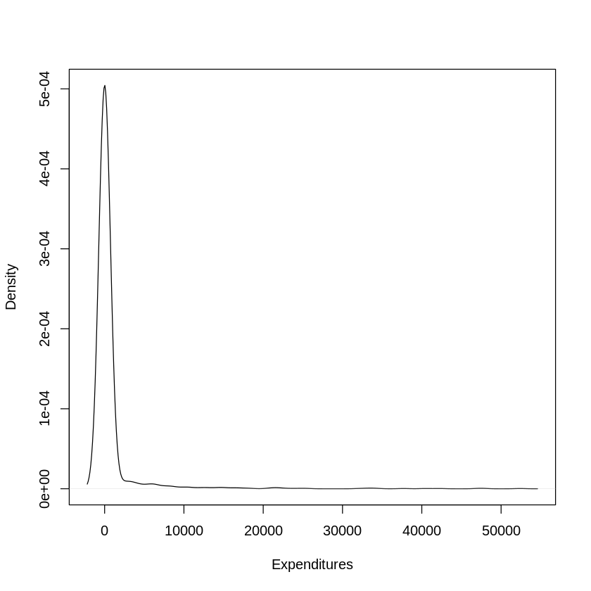

```r
# TEMPORARILY REMOVE OBS # 58

Hexpend58 <- subset(Hexpend, !(EXPENDIP>600000))
plot(density(Hexpend58$EXPENDIP), main="", xlab="Expenditures")
```

Now we examine the median by level of covariates, to try to understand which features might be important determinants of expenditures.

```r
install.packages("doBy")
library(doBy)

#  Table 13.5
#Hexpend$POSEXP <- 1*(Hexpend$EXPENDIP>0)
HexpendPos  <- subset(Hexpend, EXPENDIP > 0)

#  CREATE A SHORT FUNCTION TO SAVE WORK
fun2 <- function(group_var, summary_vars){
    # Convert group_var and summary_vars to character if they are not
  group_var <- as.character(substitute(group_var))
  summary_vars <- as.character(substitute(summary_vars))
temp <- doBy::summaryBy(
  formula = as.formula(paste(summary_vars, "~", group_var)),
        data = HexpendPos,
           FUN = function(x) { c(m = median(x), num = length(x)) } )
temp1 <- temp[,c(1,3,2)]
temp1[,2] <- round(100*temp1[,2]/length(HexpendPos$EXPENDIP), digits=1)
colnames(temp1) <- NULL
temp1[,1] <- as.character(temp1[,1])
return(as.matrix(temp1) )
}

var1 <- fun2(GENDER,EXPENDIP)
var2 <- fun2(RACE,EXPENDIP)
var3 <- fun2(REGION,EXPENDIP)
var4 <- fun2(EDUC,EXPENDIP)
var5 <- fun2(PHSTAT,EXPENDIP)
#var6 <- fun2(MPOOR,EXPENDIP)
var7 <- fun2(ANYLIMIT,EXPENDIP)
var8 <- fun2(INCOME,EXPENDIP)
var9 <- fun2(insure,EXPENDIP)

tableout <- rbind(var1, var2, var3, var4,
                  var5, var7, var8, var9)
tableout
#TableGen1(TableData=tableout,
#         TextTitle='Median Expenditures by Explanatory Variable  Based on a Sample of $n=157$ with Positive Expenditures',
#         Align='crr', ColumnSpec=1:3, ColWidth = ColWidth4 )
```

A matrix: 28 × 3 of type chr

| 1 | 0 | 28 | 7313 |
| --- | --- | --- | --- |
| 2 | 1 | 72 | 5546 |
| 1 | ASIAN | 2.5 | 4003 |
| 2 | BLACK | 19.7 | 6100 |
| 3 | NATIV | 1.9 | 2310 |
| 4 | OTHER | 1.9 | 4051 |
| 5 | WHITE | 73.9 | 5725 |
| 1 | MIDWEST | 21.7 | 7999 |
| 2 | NORTHEAST | 18.5 | 5833 |
| 3 | SOUTH | 40.8 | 5595 |
| 4 | WEST | 19.1 | 4297 |
| 1 | COLLEGE | 23.6 | 5611 |
| 2 | HIGHSCH | 43.3 | 5907 |
| 3 | LHIGHSC | 33.1 | 5338 |
| 1 | EXCE | 16.6 | 5277 |
| 2 | FAIR | 10.2 | 5228 |
| 3 | GOOD | 31.2 | 5032 |
| 4 | POOR | 17.2 | 10447 |
| 5 | VGOO | 24.8 | 5546 |
| 1 | 0 | 58.6 | 4746 |
| 2 | 1 | 41.4 | 7826 |
| 1 | HINCOME | 21.7 | 7271 |
| 2 | LINCOME | 16.6 | 6909 |
| 3 | MINCOME | 26.8 | 5851 |
| 4 | NPOOR | 7.0 | 5546 |
| 5 | POOR | 28.0 | 4097 |
| 1 | 0 | 8.9 | 2668 |
| 2 | 1 | 91.1 | 5943 |

Here is the fit of a gamma regression model with all variables.

```r
#  Table 13.6
HexpendPos  <- subset(Hexpend, EXPENDIP > 0)

#  MODEL WITH ALL VARIABLES
#  HAD TO INCREASE THE DEFAULT NUMBER OF ITERATIONS FOR CONVERGENCE
model1 = glm(EXPENDIP~COUNTIP+AGE+GENDER
    +factor(RACE)+factor(REGION)+factor(EDUC)+factor(PHSTAT)
    +MNHPOOR+ANYLIMIT+factor(INCOME)+insure,
    control = glm.control(maxit = 50),
    data=HexpendPos,family=Gamma(link="log"))
output1 <- summary(model1 )
tidy_model <- broom::tidy(model1)
tidy_model
```

A tibble: 24 × 5

| term <chr> | estimate <dbl> | std.error <dbl> | statistic <dbl> | p.value <dbl> |
| --- | --- | --- | --- | --- |
| (Intercept) | 6.21093 | 0.66412 | 9.3521 | 2.75e-16 |
| COUNTIP | 0.68207 | 0.09361 | 7.2866 | 2.53e-11 |
| AGE | 0.02057 | 0.00688 | 2.9890 | 3.34e-03 |
| GENDER | -0.23783 | 0.17207 | -1.3822 | 1.69e-01 |
| factor(RACE)BLACK | 0.18240 | 0.51238 | 0.3560 | 7.22e-01 |
| factor(RACE)NATIV | -0.69740 | 0.73213 | -0.9526 | 3.43e-01 |
| factor(RACE)OTHER | 0.72636 | 0.70706 | 1.0273 | 3.06e-01 |
| factor(RACE)WHITE | 0.51295 | 0.48134 | 1.0657 | 2.89e-01 |
| factor(REGION)NORTHEAST | -0.62758 | 0.23754 | -2.6420 | 9.23e-03 |
| factor(REGION)SOUTH | -0.25598 | 0.19873 | -1.2881 | 2.00e-01 |
| factor(REGION)WEST | -0.26085 | 0.23334 | -1.1179 | 2.66e-01 |
| factor(EDUC)HIGHSCH | 0.26118 | 0.19254 | 1.3565 | 1.77e-01 |
| factor(EDUC)LHIGHSC | 0.41110 | 0.22486 | 1.8282 | 6.98e-02 |
| factor(PHSTAT)FAIR | -0.16468 | 0.31435 | -0.5239 | 6.01e-01 |
| factor(PHSTAT)GOOD | 0.06266 | 0.22700 | 0.2760 | 7.83e-01 |
| factor(PHSTAT)POOR | 0.02635 | 0.29817 | 0.0884 | 9.30e-01 |
| factor(PHSTAT)VGOO | 0.01808 | 0.23706 | 0.0763 | 9.39e-01 |
| MNHPOOR | -0.39677 | 0.23838 | -1.6644 | 9.84e-02 |
| ANYLIMIT | -0.00578 | 0.18876 | -0.0306 | 9.76e-01 |
| factor(INCOME)LINCOME | 0.55104 | 0.25662 | 2.1473 | 3.36e-02 |
| factor(INCOME)MINCOME | 0.12269 | 0.21059 | 0.5826 | 5.61e-01 |
| factor(INCOME)NPOOR | 0.46314 | 0.35409 | 1.3080 | 1.93e-01 |
| factor(INCOME)POOR | -0.06846 | 0.25079 | -0.2730 | 7.85e-01 |
| insure | 0.78887 | 0.25717 | 3.0675 | 2.62e-03 |

With reduced variables.

```r
#  REDUCED MODEL
HexpendPos$BLACK = (HexpendPos$RACE == "BLACK")
HexpendPos$POOR = (HexpendPos$PHSTAT == "POOR")
HexpendPos$POORNEG = (HexpendPos$INCOME == "POOR")
model2 <- glm(EXPENDIP ~ COUNTIP + AGE + GENDER +
    factor(BLACK) + factor(REGION) + factor(EDUC) + factor(POOR) +
    MNHPOOR + ANYLIMIT + factor(POORNEG),
    data=HexpendPos, family=Gamma(link="log") )
summary(model2)
anova(model1, model2)
```

```
Call:
glm(formula = EXPENDIP ~ COUNTIP + AGE + GENDER + factor(BLACK) +
    factor(REGION) + factor(EDUC) + factor(POOR) + MNHPOOR +
    ANYLIMIT + factor(POORNEG), family = Gamma(link = "log"),
    data = HexpendPos)

Coefficients:
                        Estimate Std. Error t value Pr(>|t|)
(Intercept)              7.83802    0.39992   19.60  < 2e-16 ***
COUNTIP                  0.67226    0.09962    6.75  3.5e-10 ***
AGE                      0.01531    0.00689    2.22   0.0280 *
GENDER                  -0.11842    0.18328   -0.65   0.5192
factor(BLACK)TRUE       -0.25770    0.20908   -1.23   0.2198
factor(REGION)NORTHEAST -0.66219    0.25185   -2.63   0.0095 **
factor(REGION)SOUTH     -0.34000    0.21269   -1.60   0.1121
factor(REGION)WEST      -0.44784    0.25101   -1.78   0.0765 .
factor(EDUC)HIGHSCH      0.25872    0.20498    1.26   0.2089
factor(EDUC)LHIGHSC      0.46874    0.23487    2.00   0.0479 *
factor(POOR)TRUE         0.16672    0.24508    0.68   0.4974
MNHPOOR                 -0.31436    0.24289   -1.29   0.1977
ANYLIMIT                 0.05161    0.19546    0.26   0.7921
factor(POORNEG)TRUE     -0.40561    0.20250   -2.00   0.0471 *
---
Signif. codes:  0 ‘***’ 0.001 ‘**’ 0.01 ‘*’ 0.05 ‘.’ 0.1 ‘ ’ 1

(Dispersion parameter for Gamma family taken to be 0.92)

    Null deviance: 281.14  on 156  degrees of freedom
Residual deviance: 137.88  on 143  degrees of freedom
AIC: 3167

Number of Fisher Scoring iterations: 12
```

A anova: 2 × 6

|  | Resid. Df <dbl> | Resid. Dev <dbl> | Df <dbl> | Deviance <dbl> | F <dbl> | Pr(>F) <dbl> |
| --- | --- | --- | --- | --- | --- | --- |
| 1 | 133 | 124 | NA | NA | NA | NA |
| 2 | 143 | 138 | -10 | -13.9 | 1.85 | 0.0576 |

```r
#Hexpend58 <- subset(HexpendPos, !(EXPENDIP>600000))
#  REDUCED MODEL - INVERSE GAUSSIAN
#  DOES NOT WANT TO CONVERGE !!
# model3 <- glm(EXPENDIP ~ COUNTIP + AGE + GENDER +
#     factor(BLACK) + factor(REGION) + factor(EDUC) + factor(POOR) +
#     MNHPOOR + ANYLIMIT + factor(POORNEG),  control = glm.control(maxit = 100),
#     data=Hexpend58, family=inverse.gaussian(link = "log") )
# summary(model3)
#   ALSO PROBLEMS WITH family=inverse.gaussian(link = "1/mu^2")
```